# FIFA 2019 PLAYER DATASET ANALYSIS

### Introduction:

In this project, we are analysing the dataset correspondinding to the *FIFA19 Player Dataset*. *FIFA*, also known as *FIFA Football* or *FIFA Soccer*, is a series of association football video games or football simulator, released annually by Electronic Arts under the EA Sports label. Listed in Guinness World Records as the best-selling sports video game franchise in the world, by 2018, the FIFA series had sold over 260 million copies. The most recent iteration of FIFA features more than 18200 players and almost 90 player attributes worth of unprocessed data which makes it ideal for data analysis.

The dataset we used in this project can be downloaded from [here](https://www.kaggle.com/karangadiya/fifa19/download).

With this project we hope to showcase basic data cleaning, data profiling, data manipulation, calculating some basic statistics, and performing exploratory data analysis.

### Extracting the Data:

To start with the analysis, we start by importing the data. Make sure that the csv file is in the same working directory as your R environment. To get your R working directory, use the `getwd()` function. If you want to change your R working directory, you can do so by using the `setwd()` finction.

```r
rawdata <- read.csv("rawdata.csv")
head(rawdata)
```

```
##   X     ID              Name Age
## 1 0 158023          L. Messi  31
## 2 1  20801 Cristiano Ronaldo  33
## 3 2 190871         Neymar Jr  26
## 4 3 193080            De Gea  27
## 5 4 192985      K. De Bruyne  27
## 6 5 183277         E. Hazard  27
##                                            Photo Nationality
## 1 https://cdn.sofifa.org/players/4/19/158023.png   Argentina
## 2  https://cdn.sofifa.org/players/4/19/20801.png    Portugal
## 3 https://cdn.sofifa.org/players/4/19/190871.png      Brazil
## 4 https://cdn.sofifa.org/players/4/19/193080.png       Spain
## 5 https://cdn.sofifa.org/players/4/19/192985.png     Belgium
## 6 https://cdn.sofifa.org/players/4/19/183277.png     Belgium
##                                  Flag Overall Potential
```

[output cut: 90 more lines]

### Dropping Redundant Player Attributes:

Out of the ~90 player attributes, there are certain player attributes which do not contribute in our analysis for making the dream team. Thus, we consider to drop these irrelevant attributes.

```r
rawdata$X <- NULL
rawdata$Photo <- NULL
rawdata$Age <- NULL
rawdata$Nationality <- NULL
rawdata$Flag <- NULL
rawdata$Club.Logo <- NULL
rawdata$Value <- NULL
rawdata$Wage <- NULL
rawdata$Work.Rate <- NULL
rawdata$Body.Type <- NULL
rawdata$Real.Face <- NULL
rawdata$Jersey.Number <- NULL
rawdata$Joined <- NULL
rawdata$Loaned.From <- NULL
rawdata$Contract.Valid.Until <- NULL
rawdata$Height <- NULL
rawdata$Weight <- NULL
rawdata$Release.Clause <- NULL
head(rawdata)
```

```
##       ID              Name Overall Potential                Club Special
## 1 158023          L. Messi      94        94        FC Barcelona    2202
## 2  20801 Cristiano Ronaldo      94        94            Juventus    2228
## 3 190871         Neymar Jr      92        93 Paris Saint-Germain    2143
## 4 193080            De Gea      91        93   Manchester United    1471
## 5 192985      K. De Bruyne      91        92     Manchester City    2281
## 6 183277         E. Hazard      91        91             Chelsea    2142
##   Preferred.Foot International.Reputation Weak.Foot Skill.Moves Position
## 1           Left                        5         4           4       RF
## 2          Right                        5         4           5       ST
## 3          Right                        5         5           5       LW
## 4          Right                        4         3           1       GK
## 5          Right                        4         5           4      RCM
## 6          Right                        4         4           4       LF
##     LS   ST   RS   LW   LF   CF   RF   RW  LAM  CAM  RAM   LM  LCM   CM
```

[output cut: 55 more lines]

Let us now plot a histogram of the Overall score of all the players to get an understanding of the dataset we are working with.

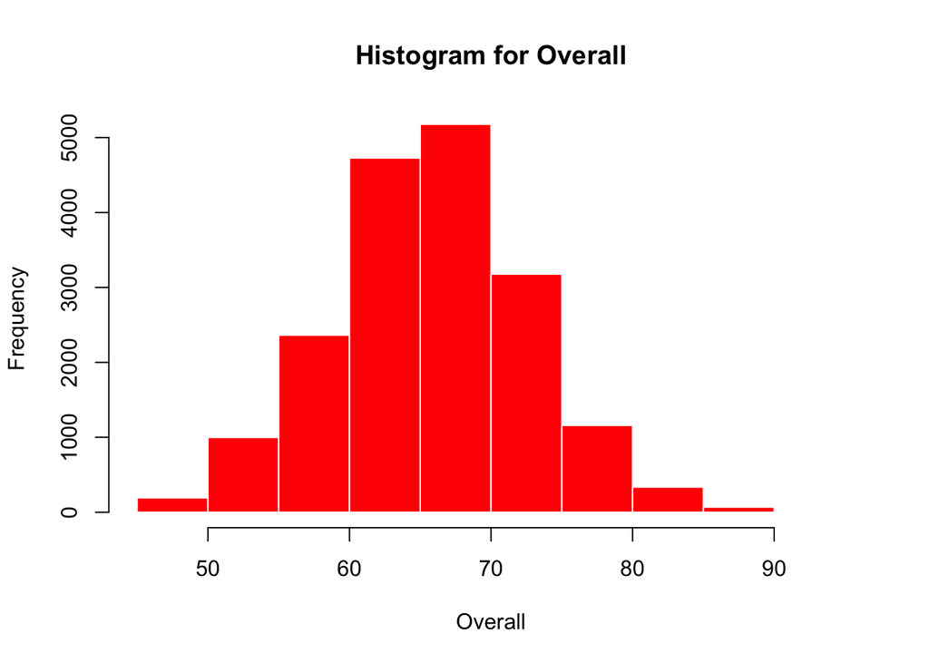

```r
hist(rawdata$Overall,col="red",border="white",xlab="Overall",main="Histogram for Overall")
```

From the histogram, we can comprehend that there are ~500 players with 80+ Overall. Thus for the sake of eliminating redundant players and reducing the dataset, we will only consider the top 500 players with the highest Overall.

```r
rawdata <- rawdata[order(-rawdata$Overall),]
rawdata <- rawdata[1:500,]
dim(rawdata)
```

```
## [1] 500  71
```

We will now export this dataset and all the actions that we perform in this project will be done on this reduced dataset.

```r
write.csv(rawdata,file = "data.csv")
data <- read.csv("data.csv")
head(data)
```

```
##   X     ID              Name Overall Potential                Club Special
## 1 1 158023          L. Messi      94        94        FC Barcelona    2202
## 2 2  20801 Cristiano Ronaldo      94        94            Juventus    2228
## 3 3 190871         Neymar Jr      92        93 Paris Saint-Germain    2143
## 4 4 193080            De Gea      91        93   Manchester United    1471
## 5 5 192985      K. De Bruyne      91        92     Manchester City    2281
## 6 6 183277         E. Hazard      91        91             Chelsea    2142
##   Preferred.Foot International.Reputation Weak.Foot Skill.Moves Position
## 1           Left                        5         4           4       RF
## 2          Right                        5         4           5       ST
## 3          Right                        5         5           5       LW
## 4          Right                        4         3           1       GK
## 5          Right                        4         5           4      RCM
## 6          Right                        4         4           4       LF
##     LS   ST   RS   LW   LF   CF   RF   RW  LAM  CAM  RAM   LM  LCM   CM
```

[output cut: 55 more lines]

### Some Considerations:

For our dream team, we are considering the 4-3-3 formation. 4-3-3 is considered to be on of the most versatile formations in football and the easiest to work with.

As such, we are looking at 1 goalkeeper, 4 defenders, 3 mids and 3 forwards. Keeping this information in mind, we would proceed further in our project.

### Choosing the Goalkeeper:

For choosing our goalkeeper, our first step would be to extract the goalkeepers from the dataset into a new dataset and drop all the irrelevant player attributes that do not correspond to a goalkeeper or won’t help us in the process of ranking a goalkeeper.

```r
gkdata <- data[data$Position=="GK",]
gkdata[,c("X","Overall","International.Reputation","Weak.Foot","Skill.Moves","LS","ST","RS","LW","LF","CF","RF","RW","LAM","CAM","RAM","LM","LCM","CM","RCM","RM","LWB","LDM","CDM","RDM","RWB","LB","LCB","CB","RCB","RB","Crossing","Finishing","HeadingAccuracy","ShortPassing","Volleys","Dribbling","Curve","FKAccuracy","LongPassing","BallControl","Acceleration","SprintSpeed","Agility","Reactions","Balance","ShotPower","Jumping","Stamina","Strength","LongShots","Aggression","Interceptions","Positioning","Vision","Penalties","Composure","Marking","StandingTackle","SlidingTackle")] <- list(NULL)
head(gkdata)
```

```
##        ID          Name Potential              Club Special Preferred.Foot
## 4  193080        De Gea        93 Manchester United    1471          Right
## 10 200389      J. Oblak        93   Atlético Madrid    1331          Right
## 19 192448 M. ter Stegen        92      FC Barcelona    1328          Right
## 20 192119   T. Courtois        90       Real Madrid    1311           Left
## 23 167495      M. Neuer        89 FC Bayern München    1473          Right
## 38 167948     H. Lloris        88 Tottenham Hotspur    1335           Left
##    Position GKDiving GKHandling GKKicking GKPositioning GKReflexes
## 4        GK       90         85        87            88         94
## 10       GK       86         92        78            88         89
## 19       GK       87         85        88            85         90
## 20       GK       85         91        72            86         88
## 23       GK       90         86        91            87         87
## 38       GK       88         84        68            83         92
```

Now, the main attributes that correspond to a goalkeepers’ performance are `GKDiving, GKHandling, GKKicking, GKPositioning, GKReflexes`. However, not all of these attributes carry equal importance in deciding a goalkeepers’ performance. So, after doing some considerable amount of research, we assign the following weightage to each of the above mentioned player attributes and calculate the weighted mean as a new attribute `GKOverall`.

- GKDiving = 2.25
- GKHandling = 1.75
- GKKicking = 1
- GKPositioning = 1.75
- GKReflexes = 3.25

```r
GKOverall = (gkdata$GKDiving*2.25+gkdata$GKHandling*1.75+gkdata$GKKicking*1+gkdata$GKPositioning*1.75+gkdata$GKReflexes*3.25)/10
gkdata <- cbind(gkdata,GKOverall)
```

```r
gkdata[order(-GKOverall),]
```

```
##         ID             Name Potential                     Club Special
## 4   193080           De Gea        93        Manchester United    1471
## 23  167495         M. Neuer        89        FC Bayern München    1473
## 10  200389         J. Oblak        93          Atlético Madrid    1331
## 19  192448    M. ter Stegen        92             FC Barcelona    1328
## 41  162835    S. Handanovič        88                    Inter    1262
## 20  192119      T. Courtois        90              Real Madrid    1311
## 38  167948        H. Lloris        88        Tottenham Hotspur    1335
## 47  193041         K. Navas        87              Real Madrid    1345
## 42    1179        G. Buffon        88      Paris Saint-Germain    1334
## 58  210257          Ederson        90          Manchester City    1463
## 82  212831          Alisson        90                Liverpool    1320
## 127 199482         A. Lopes        86       Olympique Lyonnais    1355
## 93  186153      W. Szczęsny        87                 Juventus    1270
## 129 198009         M. Perin        89                 Juventus    1254
```

[output cut: 159 more lines]

```r
dreamteam <- rbind(data[data$ID=="193080",])
```

### Choosing the Defenders:

For choosing our defenders, our first step would be to extract the defenders(CB, LB, LCB, RB, RCB) from the dataset into a new dataset and drop all the irrelevant player attributes that do not correspond to a defender or won’t help us in the process of ranking a defender.

```r
defdata <- data[data$Position==c("CB","LB","RB","LCB","RCB"),]
defdata[,c("X","Overall","International.Reputation","Weak.Foot","Skill.Moves","LS","ST","RS","LW","LF","CF","RF","RW","LAM","CAM","RAM","LM","LCM","CM","RCM","RM","LWB","LDM","CDM","RDM","RWB","LB","LCB","CB","RCB","RB","Crossing","Finishing","HeadingAccuracy","Volleys","Dribbling","Curve","FKAccuracy","Agility","Balance","ShotPower","Jumping","LongShots","Aggression","Vision","Penalties","Composure","GKDiving","GKHandling","GKKicking","GKPositioning","GKReflexes")] <- list(NULL)
head(defdata)
```

```
##         ID         Name Potential                Club Special
## 40  164240 Thiago Silva        88 Paris Saint-Germain    2077
## 55  152729        Piqué        87        FC Barcelona    1950
## 89  192774   K. Manolas        87                Roma    1642
## 107 164169  Filipe Luís        85     Atlético Madrid    2145
## 114 212218   A. Laporte        88     Manchester City    1912
## 116 212190      N. Süle        90   FC Bayern München    1648
##     Preferred.Foot Position ShortPassing LongPassing BallControl
## 40           Right      RCB           80          80          80
## 55           Right      RCB           81          80          78
## 89           Right      LCB           60          61          65
## 107           Left       LB           80          77          83
## 114           Left      LCB           76          78          73
## 116          Right       CB           78          63          63
##     Acceleration SprintSpeed Reactions Stamina Strength Interceptions
## 40            70          72        82      74       82            89
## 55            49          60        84      65       83            88
## 89            80          85        85      76       82            86
## 107           76          75        85      89       74            84
## 114           62          66        83      67       82            85
## 116           52          84        79      65       94            82
##     Positioning Marking StandingTackle SlidingTackle
## 40           59      88             89            85
## 55           58      91             86            84
## 89           25      86             87            89
## 107          71      78             84            86
## 114          54      85             86            87
## 116          26      82             85            83
```

Now, the main attributes that correspond to a defenders’ performance are `Positioning, StandingTackle, SlidingTackle, ShortPassing, LongPassing, Strength, Stamina, Reactions, BallControl, Acceleration, SprintSpeed, Interceptions, Marking`. However, not all of these attributes carry equal importance in deciding a goalkeepers’ performance. So, after doing some considerable amount of research, we assign the following weightage to each of the above mentioned player attributes and calculate the weighted mean as a new attribute `DefOverall`.

- Positioning = 2
- StandingTackle = 2.5
- SlidingTackle = 2.5
- ShortPassing = 1.5
- LongPassing = 1.5
- Strength = 0.5
- Stamina = 0.5
- Reactions = 0.25
- BallControl = 1
- Acceleration = 0.5
- SprintSpeed = 0.5
- Interceptions = 2
- Marking = 2

```r
DefOverall <- ((defdata$Positioning*2+defdata$StandingTackle*2.5+defdata$SlidingTackle*2.5+defdata$ShortPassing*1.5+defdata$LongPassing*1.5+defdata$Strength*0.5+defdata$Stamina*0.5+defdata$Reactions*0.25+defdata$BallControl*1+defdata$Acceleration*0.5+defdata$SprintSpeed*0.5+defdata$Interceptions*2+defdata$Marking*2)/17.25)
defdata <- cbind(defdata,DefOverall)
```

To get the defenders for our dream team, we will sort the `DefOverall` attribute and take the highest scores. As mentioned earlier, the formation we are going for is 4-3-3. So, we would require 2 CBs, 1 LB and 1 RB.  
The defenders are then appended to the dataset `dreamteam`

```r
defdata[order(-DefOverall),]
```

```
##         ID             Name Potential                Club Special
## 40  164240     Thiago Silva        88 Paris Saint-Germain    2077
## 107 164169      Filipe Luís        85     Atlético Madrid    2145
## 193 199564    Sergi Roberto        86        FC Barcelona    2106
## 55  152729            Piqué        87        FC Barcelona    1950
## 248 210514     João Cancelo        88            Juventus    2174
## 292 185103       A. Kolarov        82                Roma    2230
## 393 173771      L. Piszczek        81   Borussia Dortmund    2128
## 114 212218       A. Laporte        88     Manchester City    1912
## 483 197853        S. Aurier        83   Tottenham Hotspur    2091
## 397 169595          D. Rose        81   Tottenham Hotspur    2094
## 370 193532         G. Medel        81         Beşiktaş JK    1996
## 493 192789     Mario Gaspar        80       Villarreal CF    2081
## 242 216267     A. Robertson        87           Liverpool    2023
## 418 234035        Odriozola        88         Real Madrid    1991
```

[output cut: 101 more lines]

```r
dreamteam <- rbind(dreamteam,data[data$ID=="164240",])
dreamteam <- rbind(dreamteam,data[data$ID=="152729",])
dreamteam <- rbind(dreamteam,data[data$ID=="164169",])
dreamteam <- rbind(dreamteam,data[data$ID=="199564",])
```

### Choosing the Midfielders:

For choosing our midfielder, our first step would be to extract the mids(CM, CAM, LM, LAM, LCM, RM, RAM, RCM) from the dataset into a new dataset and drop all the irrelevant player attributes that do not correspond to a midfielder or won’t help us in the process of ranking a midfielder.

```r
middata <- data[data$Position==c("CM","CAM","LM","LAM","LCM","RM","RAM","RCM"),]
middata[,c("X","Overall","International.Reputation","Weak.Foot","Skill.Moves","LS","ST","RS","LW","LF","CF","RF","RW","LAM","CAM","RAM","LM","LCM","CM","RCM","RM","LWB","LDM","CDM","RDM","RWB","LB","LCB","CB","RCB","RB","Balance","Interceptions","Positioning","Composure","Marking","StandingTackle","SlidingTackle","GKDiving","GKHandling","GKKicking","GKPositioning","GKReflexes")] <- list(NULL)
head(middata)
```

```
##         ID         Name Potential                Club Special
## 18  194765 A. Griezmann        90     Atlético Madrid    2246
## 53  171877    M. Hamšík        87              Napoli    2188
## 59  208722      S. Mané        87           Liverpool    2110
## 137 186942  I. Gündoğan        84     Manchester City    2138
## 169 210008    A. Rabiot        87 Paris Saint-Germain    2184
## 185 202166   J. Draxler        86 Paris Saint-Germain    2112
##     Preferred.Foot Position Crossing Finishing HeadingAccuracy
## 18            Left      CAM       82        90              84
## 53           Right      LCM       78        79              74
## 59           Right       LM       73        84              62
## 137          Right       CM       74        73              50
## 169           Left       CM       70        69              77
## 185          Right       CM       83        78              65
##     ShortPassing Volleys Dribbling Curve FKAccuracy LongPassing
```

[output cut: 20 more lines]

Now, the main attributes that correspond to a midfielders’ performance are `Crossing, Finishing, HeadingAccuracy, ShortPassing, Volleys, Dribbling, Curve, FKAccuracy, LongPassing, BallControl, Acceleration, SprintSpeed, Agility, Reactions, ShotPower, Jumping, Stamina, Strength, LongShots, Aggression, Vision, Penalties`. However, not all of these attributes carry equal importance in deciding a goalkeepers’ performance. So, after doing some considerable amount of research, we assign the following weightage to each of the above mentioned player attributes and calculate the weighted mean as a new attribute `MidOverall`.

- Crossing = 2.5
- Finishing = 3
- HeadingAccuracy = 1.5
- ShortPassing = 2.5
- Volleys = 2.5
- Dribbling = 2.5
- Curve = 1.5
- FKAccuracy = 3
- LongPassing = 2.5
- BallControl = 3
- Acceleration = 1.5
- SprintSpeed = 1.5
- Agility = 1.5
- Reactions = 0.75
- ShotPower = 1.5
- Jumping = 0.75
- Stamina = 0.75
- Strength = 0.75
- LongShots = 3
- Aggression = 0.75
- Vision = 0.75
- Penalties = 1.5

```r
MidOverall <- ((middata$Crossing*2.5+middata$Finishing*3+middata$HeadingAccuracy*1.5+middata$ShortPassing*2.5+middata$Volleys*2.5+middata$Dribbling*2.5+middata$Curve*1.5+middata$FKAccuracy*3+middata$LongPassing*2.5+middata$BallControl*3+middata$Acceleration*1.5+middata$SprintSpeed*1.5+middata$Agility*1.5+middata$Reactions*0.75+middata$ShotPower*1.5+middata$Jumping*0.75+middata$Stamina*0.75+middata$Strength*0.75+middata$LongShots*3+middata$Aggression*0.75+middata$Vision*0.75+middata$Penalties*1.5)/38.75)
middata <- cbind(middata,MidOverall)
```

To get the midfielders for our dream team, we will sort the `MidOverall` attribute and take the highest scores. As mentioned earlier, the formation we are going for is 4-3-3. So, we would 1 CM, 1 LM and 1 RM. The midfielders are then appended to the dataset `dreamteam`

```r
middata[order(-MidOverall),]
```

```
##         ID           Name Potential                Club Special
## 18  194765   A. Griezmann        90     Atlético Madrid    2246
## 185 202166     J. Draxler        86 Paris Saint-Germain    2112
## 53  171877      M. Hamšík        87              Napoli    2188
## 59  208722        S. Mané        87           Liverpool    2110
## 450 208128  H. Çalhanoğlu        84               Milan    2085
## 281 192318       M. Götze        85   Borussia Dortmund    2101
## 490 193886      D. Didavi        80       VfB Stuttgart    2056
## 137 186942    I. Gündoğan        84     Manchester City    2138
## 235 224411 Gonçalo Guedes        86         Valencia CF    2006
## 169 210008      A. Rabiot        87 Paris Saint-Germain    2184
## 290 186561      A. Ramsey        83             Arsenal    2110
## 438 215785       K. Baldé        85               Inter    1921
## 229 230658         Arthur        90        FC Barcelona    2120
## 338 212814     João Mário        84               Inter    2055
```

[output cut: 87 more lines]

```r
dreamteam <- rbind(dreamteam,data[data$ID=="194765",])
dreamteam <- rbind(dreamteam,data[data$ID=="171877",])
dreamteam <- rbind(dreamteam,data[data$ID=="202166",])
```

### Choosing the Forwards:

For choosing our forwards, our first step would be to extract the forwards(ST, CF, RF, RS, RW, LF, LS, LW) from the dataset into a new dataset and drop all the irrelevant player attributes that do not correspond to a forward or won’t help us in the process of ranking a forward.

```r
fordata <- data[data$Position==c("ST","CF","RF","RS","RW","LF","LS","LW"),]
fordata[,c("X","Overall","International.Reputation","Weak.Foot","Skill.Moves","LS","ST","RS","LW","LF","CF","RF","RW","LAM","CAM","RAM","LM","LCM","CM","RCM","RM","LWB","LDM","CDM","RDM","RWB","LB","LCB","CB","RCB","RB","Balance","Interceptions","Positioning","Composure","Marking","StandingTackle","SlidingTackle","GKDiving","GKHandling","GKKicking","GKPositioning","GKReflexes")] <- list(NULL)
head(fordata)
```

```
##        ID        Name Potential              Club Special Preferred.Foot
## 6  183277   E. Hazard        91           Chelsea    2142          Right
## 17 202126     H. Kane        91 Tottenham Hotspur    2165          Right
## 39 167664  G. Higuaín        88             Milan    1965          Right
## 49 192387 C. Immobile        87             Lazio    2009          Right
## 51 175943  D. Mertens        87            Napoli    2043          Right
## 56 222492     L. Sané        92   Manchester City    2090           Left
##    Position Crossing Finishing HeadingAccuracy ShortPassing Volleys
## 6        LF       81        84              61           89      80
## 17       ST       75        94              85           80      84
## 39       LS       68        92              80           75      90
## 49       ST       55        90              81           74      87
## 51       RF       77        86              35           82      70
## 56       LW       83        81              72           79      85
##    Dribbling Curve FKAccuracy LongPassing BallControl Acceleration
```

[output cut: 20 more lines]

Now, the main attributes that correspond to a forwards’ performance are `Crossing, Finishing, HeadingAccuracy, ShortPassing, Volleys, Dribbling, Curve, FKAccuracy, LongPassing, BallControl, Acceleration, SprintSpeed, Agility, Reactions, ShotPower, Jumping, Stamina, Strength, LongShots, Aggression, Vision, Penalties`. However, not all of these attributes carry equal importance in deciding a forwards’ performance. So, after doing some considerable amount of research, we assign the following weightage to each of the above mentioned player attributes and calculate the weighted mean as a new attribute `ForOverall`.

- Crossing = 2.5
- Finishing = 3
- HeadingAccuracy = 1.5
- ShortPassing = 2.5
- Volleys = 2.5
- Dribbling = 2.5
- Curve = 1.5
- FKAccuracy = 3
- LongPassing = 2.5
- BallControl = 3
- Acceleration = 1.5
- SprintSpeed = 1.5
- Agility = 1.5
- Reactions = 0.75
- ShotPower = 1.5
- Jumping = 0.75
- Stamina = 0.75
- Strength = 0.75
- LongShots = 3
- Aggression = 0.75
- Vision = 0.75
- Penalties = 1.5

```r
ForOverall <- ((fordata$Crossing*2.5+fordata$Finishing*3+fordata$HeadingAccuracy*1.5+fordata$ShortPassing*2.5+fordata$Volleys*2.5+fordata$Dribbling*2.5+fordata$Curve*1.5+fordata$FKAccuracy*3+fordata$LongPassing*2.5+fordata$BallControl*3+fordata$Acceleration*1.5+fordata$SprintSpeed*1.5+fordata$Agility*1.5+fordata$Reactions*0.75+fordata$ShotPower*1.5+fordata$Jumping*0.75+fordata$Stamina*0.75+fordata$Strength*0.75+fordata$LongShots*3+fordata$Aggression*0.75+fordata$Vision*0.75+fordata$Penalties*1.5)/38.75)
fordata <- cbind(fordata,ForOverall)
```

To get the forwards for our dream team, we will sort the `ForOverall` attribute and take the highest scores. As mentioned earlier, the formation we are going for is 4-3-3. So, we would require 1 CF, 1 LW and 1 RW.  
The forwards are then appended to the dataset `dreamteam`

```r
fordata[order(-ForOverall),]
```

```
##         ID            Name Potential              Club Special
## 6   183277       E. Hazard        91           Chelsea    2142
## 17  202126         H. Kane        91 Tottenham Hotspur    2165
## 56  222492         L. Sané        92   Manchester City    2090
## 51  175943      D. Mertens        87            Napoli    2043
## 85  204485       R. Mahrez        85   Manchester City    2031
## 295 184200   M. Arnautović        82   West Ham United    2106
## 237 222737          Malcom        89      FC Barcelona    1984
## 207 186627    M. Balotelli        83          OGC Nice    1914
## 320 231677     M. Rashford        89 Manchester United    2062
## 268 199451   W. Ben Yedder        82        Sevilla FC    2042
## 404 159261 F. Quagliarella        81         Sampdoria    1933
## 39  167664      G. Higuaín        88             Milan    1965
## 141 180403         Willian        84           Chelsea    2052
## 173 208618   Lucas Vázquez        83       Real Madrid    2048
```

[output cut: 117 more lines]

```r
dreamteam <- rbind(dreamteam,data[data$ID=="202126",])
dreamteam <- rbind(dreamteam,data[data$ID=="183277",])
dreamteam <- rbind(dreamteam,data[data$ID=="175943",])
```

### Result and Some Further EDA:

So, we finally have our dream team ready.

```r
dreamteam
```

```
##       X     ID          Name Overall Potential                Club Special
## 4     4 193080        De Gea      91        93   Manchester United    1471
## 40   40 164240  Thiago Silva      88        88 Paris Saint-Germain    2077
## 55   55 152729         Piqué      87        87        FC Barcelona    1950
## 107 107 164169   Filipe Luís      85        85     Atlético Madrid    2145
## 193 193 199564 Sergi Roberto      83        86        FC Barcelona    2106
## 18   18 194765  A. Griezmann      89        90     Atlético Madrid    2246
## 53   53 171877     M. Hamšík      87        87              Napoli    2188
## 185 185 202166    J. Draxler      83        86 Paris Saint-Germain    2112
## 17   17 202126       H. Kane      89        91   Tottenham Hotspur    2165
## 6     6 183277     E. Hazard      91        91             Chelsea    2142
## 51   51 175943    D. Mertens      87        87              Napoli    2043
##     Preferred.Foot International.Reputation Weak.Foot Skill.Moves Position
## 4            Right                        4         3           1       GK
## 40           Right                        4         3           2      RCB
```

[output cut: 105 more lines]

We now plot Potential Scores of the players in our dream team to get a rough estimate of the stats of the players. As we can see from the plot, all the players in our team avaerage an FIFA Potential Score of 85+ with the goalkeeper, one midfielder and two forwards averaging 90+.

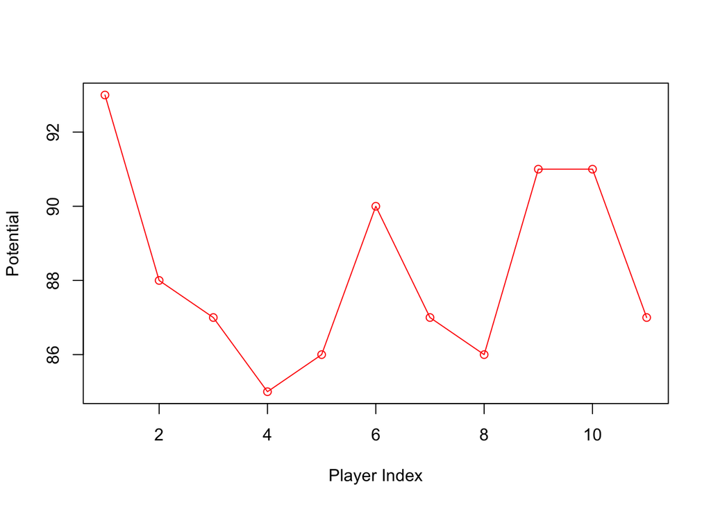

```r
plot(dreamteam$Potential,type="o",xlab="Player Index",ylab="Potential",col="red")
```

We also wish to see which club frequent in our dream team and how all the clubs compare when it comes to having the most number of players oon our dream team.

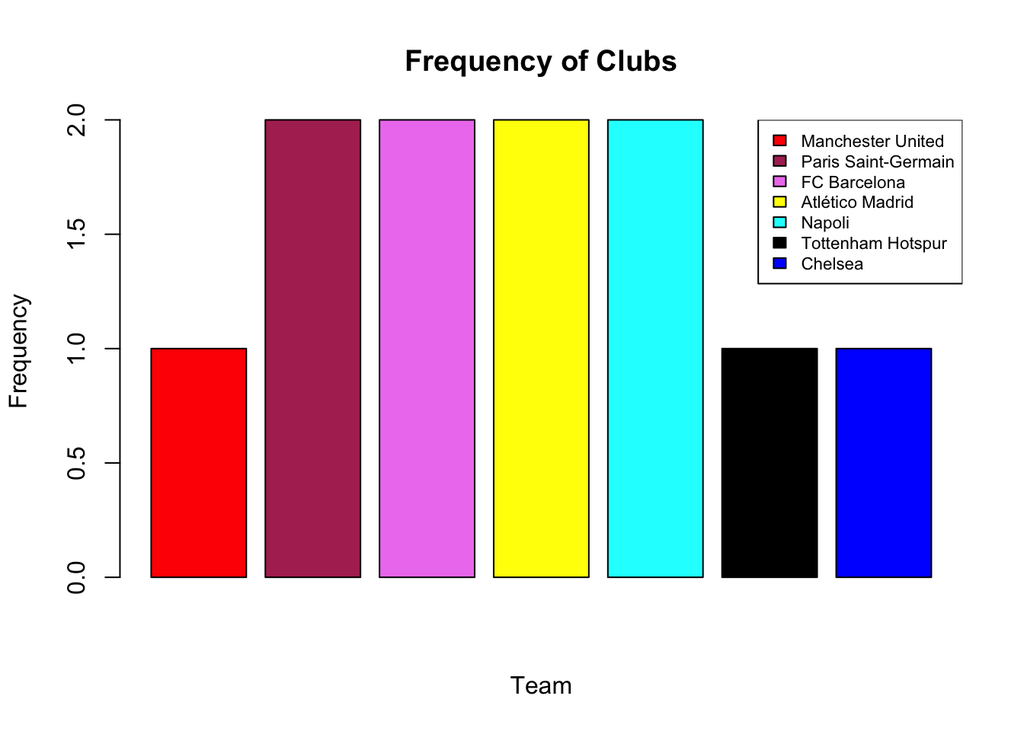

```r
mun=sum(dreamteam$Club=="Manchester United")
psg=sum(dreamteam$Club=="Paris Saint-Germain")
fcb=sum(dreamteam$Club=="FC Barcelona")
atm=sum(dreamteam$Club=="Atlético Madrid")
npi=sum(dreamteam$Club=="Napoli")
tth=sum(dreamteam$Club=="Tottenham Hotspur")
chl=sum(dreamteam$Club=="Chelsea")
team<-c(mun,psg,fcb,atm,npi,tth,chl)
teamname<-c("Manchester United","Paris Saint-Germain","FC Barcelona","Atlético Madrid","Napoli","Tottenham Hotspur","Chelsea")
colors=c("red","maroon","violet","yellow","cyan","black","blue")
barplot(team,main="Frequency of Clubs",xlab="Team",ylab="Frequency",col=colors)
legend("topright",teamname,fill=colors,cex=0.70)
```

Finally, we wish to get a ratio of the preferred foot for the players in our team.

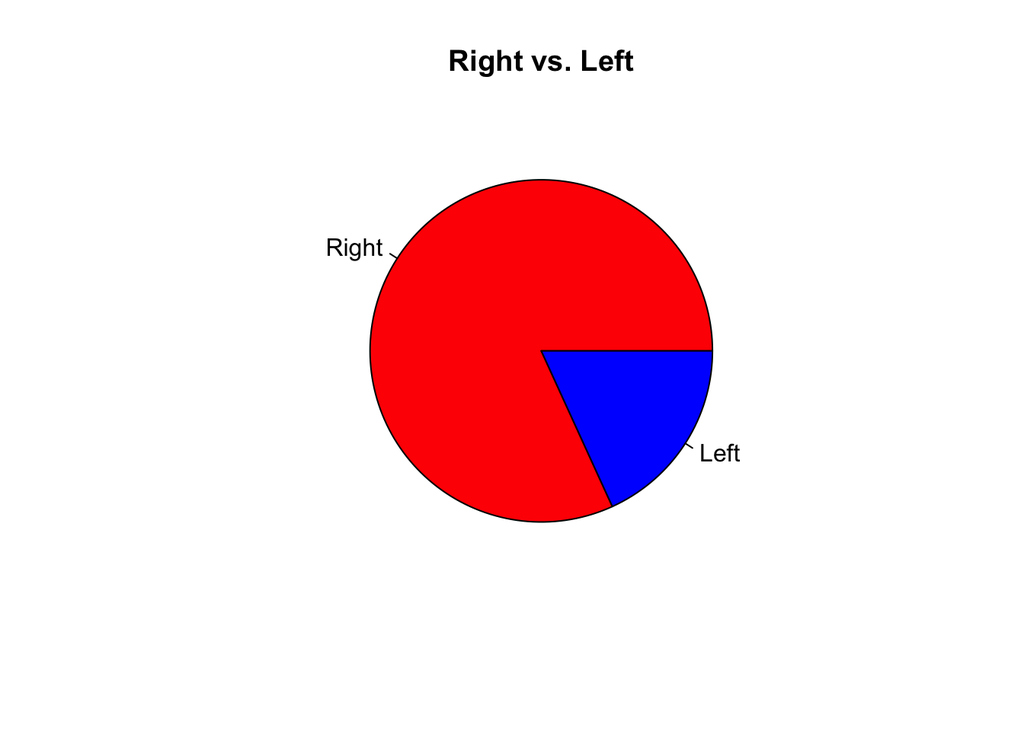

```r
right=sum(dreamteam$Preferred.Foot=="Right")
left=sum(dreamteam$Preferred.Foot=="Left")
x <- c(right,left)
labels<-c("Right","Left")
pie(x,labels,main="Right vs. Left",col=c("red","blue"))
```